# project 1

Yuyao Wang yw3395

2/2/2020

library(tm) library(purrr) library(tibble) library(textdata) library(data.table) library(tidytext) library(tidyverse) library(DT) library(vcd) library(rstan) library(dplyr) library(stringr) library(wordcloud2) library(gridExtra) library(ggplot2) library(ngram) library(tidyr) library(PerformanceAnalytics) library(stringr) library(wordcloud2) library(RColorBrewer) library(wordcloud) library(reshape2) library(scales)

```r
load("../output/processed_lyrics.RData")
```

```r
corpus1<- VCorpus(VectorSource(dt_lyrics$lyrics))
#create a tidy data structure
word_text<- tidy(corpus1) %>%
  select(id,text)
#break the text into individual tokens
word_df=word_text%>%
  unnest_tokens(word, text)%>%
  as_tibble()
```

###Preliminary word frequency analysis

We first perform a word frequency analysis on the lyrics. But it turned out that it didn’t make much sense. Because common words are some particle or prepositions, conjunctions, etc., such as the, am, and etc. This will be described in detail below.

To be specific, first, we create word frequency matrix a nd view high frequency vocabulary.

```r
frequencies <- DocumentTermMatrix(corpus1)
frequencies
```

```
## <<DocumentTermMatrix (documents: 125704, terms: 286988)>>
## Non-/sparse entries: 11249855/36064289697
## Sparsity           : 100%
## Maximal term length: 248
## Weighting          : term frequency (tf)
```

```r
findFreqTerms(frequencies, lowfreq=20000)
# lowfre = 20000 means the terms that appear at least 20000 times
```

[output not shown]

It can be seen that there are 125704 observations and 286988 words in the equivalence.

Also, we found that “’cause”,“about”，“again”,“ain’t”,“all”,“alone”,“always”,“i’ll”,“i’m”, “i’ve”,“inside”,“into”, “it”,"it’s…these words have appeared more than 20000 times in total. Create visualizations of the most common words.We found that almost all of these high-frequency words are prepositions or particle parts, which have nothing to do with emotion.

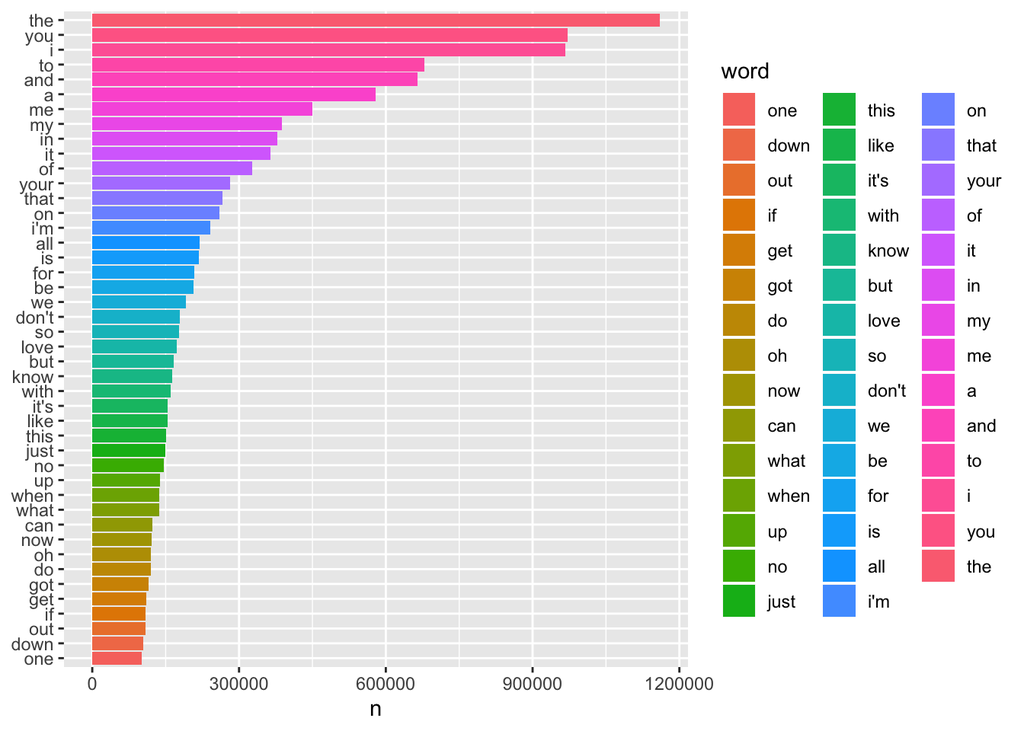

```r
word_df%>%
  count(word, sort = TRUE) %>%
  filter(n > 100000) %>%
  mutate(word = reorder(word, n)) %>%
  ggplot(aes(word, n, fill=word)) +
  geom_col() +
  xlab(NULL) +
  coord_flip()
```

Check the word frequency of the lyrics

```r
dt_lyrics=dt_lyrics%>%
  mutate(id=as.character(id))
word_df2<- tidy(corpus1) %>%
  left_join(dt_lyrics,by="id")%>%
  select(text,genre) %>%
  mutate(id = row_number()) %>%
  unnest_tokens(word, text)

frequency <- word_df2%>%
  group_by(genre) %>%
  count(word, sort = TRUE) %>%
  left_join(word_df2%>%
              group_by(genre) %>%
              summarise(total = n())) %>%
  mutate(freq = n/total)%>%
  select(genre,word,freq)%>%
  pivot_wider(id_cols=word, names_from = "genre", values_from = "freq")
frequency
```

```
## # A tibble: 123,603 x 14
##    word    Rock    Pop `Hip-Hop`   Metal Country `Not Available`    Jazz
##    <chr>  <dbl>  <dbl>     <dbl>   <dbl>   <dbl>           <dbl>   <dbl>
##  1 the   0.0411 0.0334    0.0395 0.0526   0.0381          0.0393 0.0362
##  2 you   0.0333 0.0421    0.0288 0.0243   0.0298          0.0342 0.0351
##  3 i     0.0333 0.0386    0.0304 0.0262   0.0346          0.0320 0.0330
##  4 to    0.0241 0.0233    0.0206 0.0246   0.0229          0.0237 0.0236
##  5 and   0.0238 0.0215    0.0211 0.0206   0.0277          0.0230 0.0244
##  6 a     0.0204 0.0175    0.0212 0.0178   0.0235          0.0195 0.0225
##  7 me    0.0149 0.0198    0.0136 0.0120   0.0153          0.0159 0.0173
##  8 in    0.0134 0.0118    0.0121 0.0154   0.0133          0.0129 0.0137
##  9 my    0.0125 0.0142    0.0140 0.0142   0.0137          0.0132 0.0156
## 10 it    0.0122 0.0142    0.0147 0.00890  0.0103          0.0119 0.00970
## # … with 123,593 more rows, and 6 more variables: Electronic <dbl>,
## #   `R&B` <dbl>, Indie <dbl>, Folk <dbl>, Other <dbl>, `NA` <dbl>
```

We can compare the frequency of lyrics in different genres by simply drawing a picture. However, since the frequency of occurrence is prepositions or conjunctions, such as the, and, it, etc., this comparison is actually meaningless when the data is very large.

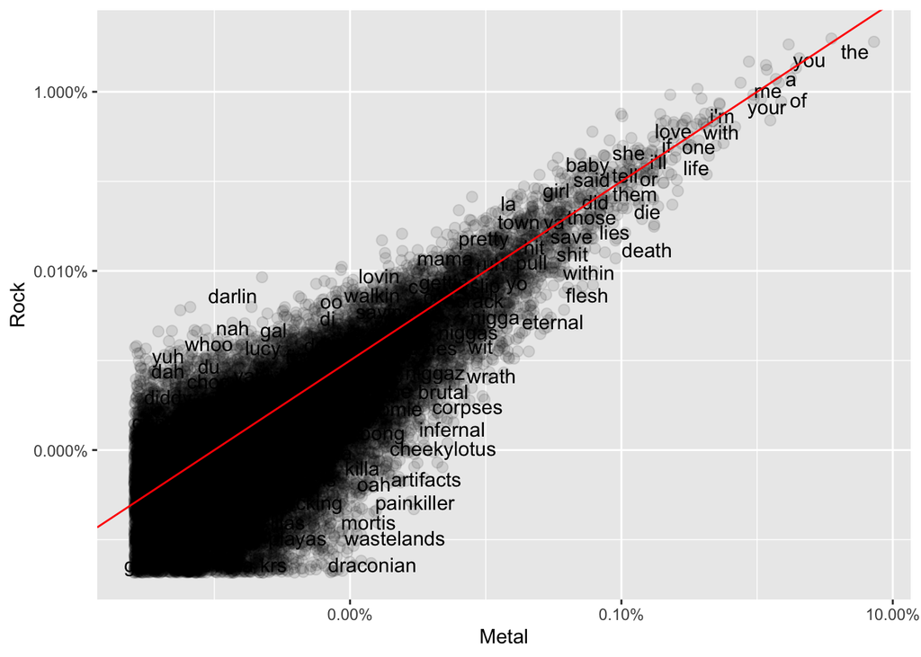

```r
ggplot(frequency, aes(Metal,Rock)) +
  geom_jitter(alpha = 0.1, size = 2.5, width = 0.25, height = 0.25) +
  geom_text(aes(label = word), check_overlap = TRUE, vjust = 1.5) +
  scale_x_log10(labels = percent_format()) +
  scale_y_log10(labels = percent_format()) +
  geom_abline(color = "red")
```

###Text sentiment analysis

Because songs are an important way for people to express their emotions, the melody and lyrics of the songs are infiltrated with different emotions. Thus, next we will analyze it from the perspective of emotions. Observing different types of music, commonly expressing emotions (positive and negative). We first use a dictionary to distinguish between these words. (Positive or negative)

there are a variety of methods and dictionaries that exist for evaluating the opinion or emotion in text. The tidytext package contains several sentiment lexicons. Three general-purpose lexicons are AFINN from Finn Årup Nielsen, bing from Bing Liu and collaborators, and nrc from Saif Mohammad and Peter Turney. All three of these lexicons are based on unigrams, i.e., single words.

Firstly, I use bing lexicon to get the dictionary and then match the words with our dataset.

###1.the frequency of expressing emotional words

```r
bing_pos<-get_sentiments("bing") %>%
  filter(sentiment=="positive")
bing_neg<-get_sentiments("bing") %>%
  filter(sentiment=="negative")

count_pos<-word_df%>%
  inner_join(bing_pos,by = "word") %>%
  count(word)
count_neg<-word_df%>%
  inner_join(bing_neg,by = "word") %>%
  count(word)

bing_word_counts <-word_df%>%
  inner_join(get_sentiments("bing"),by = "word") %>%
  count(word, sentiment, sort = TRUE) %>%
  ungroup()
bing_word_counts
```

```
## # A tibble: 5,486 x 3
##    word   sentiment      n
##    <chr>  <chr>      <int>
##  1 love   positive  173237
##  2 like   positive  153267
##  3 right  positive   55446
##  4 good   positive   40817
##  5 well   positive   40522
##  6 better positive   27228
##  7 hard   negative   21386
##  8 fall   negative   21147
##  9 lost   negative   19827
## 10 wrong  negative   19413
## # … with 5,476 more rows
```

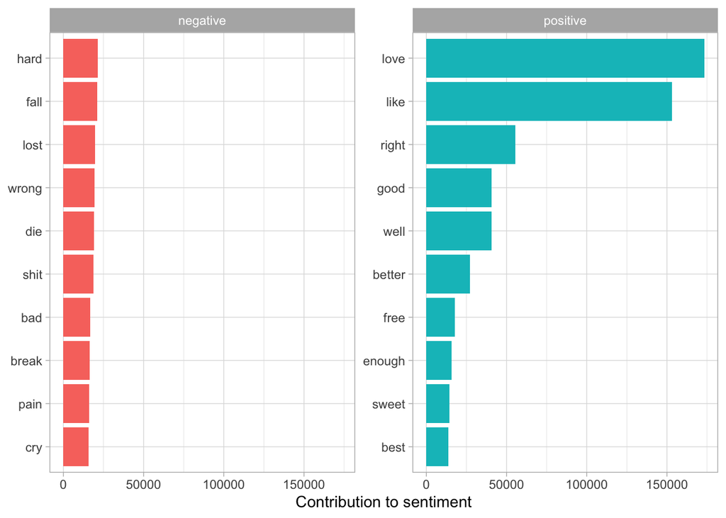

```r
bing_word_counts %>%
  group_by(sentiment) %>%
  top_n(10) %>%
  ungroup() %>%
  mutate(word = reorder(word, n)) %>%
  ggplot(aes(word, n, fill = sentiment)) +
  geom_col(show.legend = FALSE) +
  facet_wrap(~sentiment, scales = "free_y") +
  labs(y = "Contribution to sentiment",
       x = NULL) +
  coord_flip()+
  theme_light()
```

Using the wordcloud, we draw the words with the most occurrences of positive and negative words. The larger the shape of the word, the more times it appears.

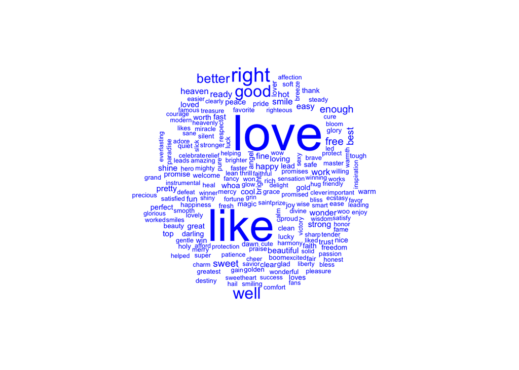

```r
wordcloud_pos<-word_df%>%
  inner_join(bing_pos,by = "word") %>%
  count(word) %>%
  with(wordcloud(word, n, max.words = 200,color="blue"))
```

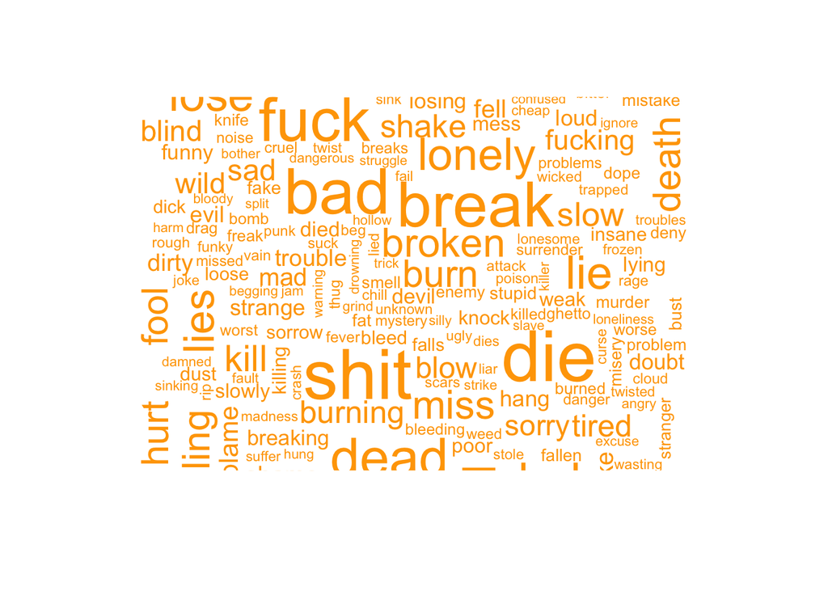

```r
wordcloud_neg<-word_df%>%
  inner_join(bing_neg,by = "word") %>%
  count(word) %>%
  with(wordcloud(word, n, max.words = 200,color="orange"))
```

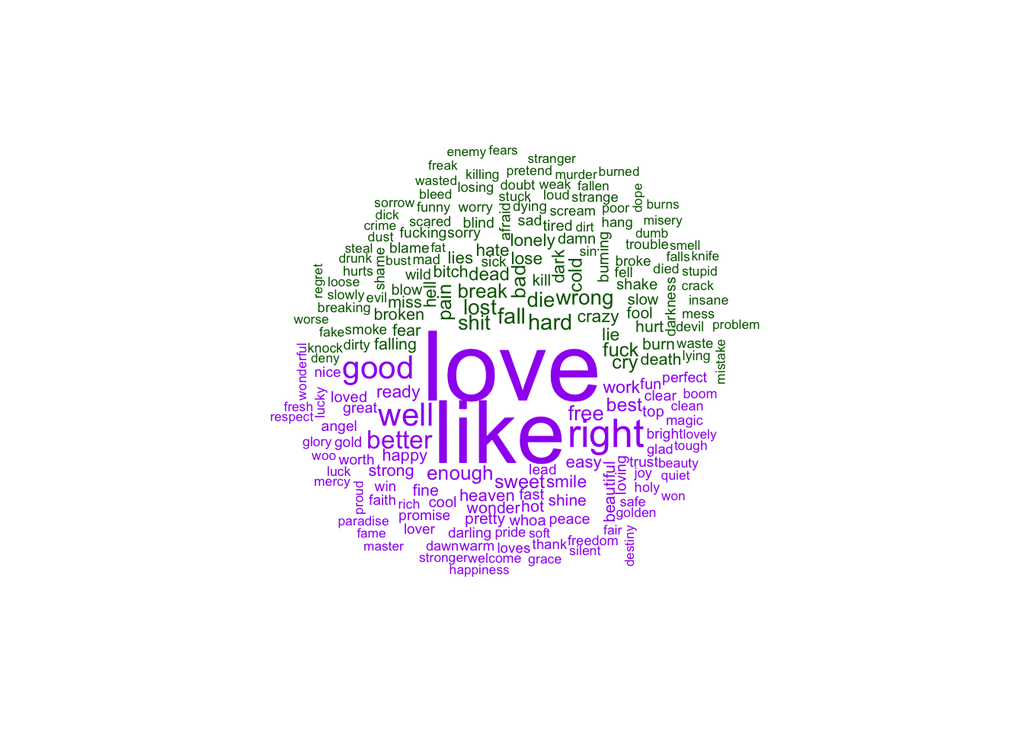

```r
wordcloud_both<-word_df%>%
  inner_join(get_sentiments("bing"),by = "word") %>%
  count(word, sentiment, sort = TRUE) %>%
  acast(word ~ sentiment, value.var = "n", fill = 0) %>%
  comparison.cloud(colors = c("dark green", "purple"),
                   max.words = 200)
```

###2. the word strength of positive and negative emotions in different songs

Next, we divide according to different genresm and compare sentiments among different genre.It’s worth looking deeper to understand why some genre ended up more positive or negative than others. For that, we can examine the total positive and negative contributions among each genre.

```r
wordsentiment_pos_genre<-word_df2%>%
  inner_join(bing_pos,by = "word") %>%
  group_by(genre)%>%
  count(word) %>%
  ungroup()

wordsentiment_neg_genre<-word_df2%>%
  inner_join(bing_neg,by = "word") %>%
  group_by(genre)%>%
  count(word) %>%
  ungroup()

sumsentiment_neg_genre=wordsentiment_neg_genre%>%
  group_by(genre)%>%
  select(-word)%>%
  mutate(sum_genre_neg=sum(n))%>%
  ungroup()%>%
  select(genre,sum_genre_neg)%>%
  distinct()
sumsentiment_neg_genre
```

```
## # A tibble: 13 x 2
##    genre         sum_genre_neg
##    <chr>                 <int>
##  1 Country               45704
##  2 Electronic            22298
##  3 Folk                   4037
##  4 Hip-Hop              194011
##  5 Indie                 10139
##  6 Jazz                  20363
##  7 Metal                150713
##  8 Not Available         28162
##  9 Other                  1237
## 10 Pop                  149262
## 11 R&B                   16253
## 12 Rock                 521838
## 13 <NA>                    278
```

```r
sumsentiment_pos_genre=wordsentiment_pos_genre%>%
  group_by(genre)%>%
  select(-word)%>%
  mutate(sum_genre_pos=sum(n))%>%
  ungroup()%>%
  select(genre,sum_genre_pos)%>%
   distinct()

genre_n=dt_lyrics%>%
  group_by(genre)%>%
  count()

sumsentiment_genre=sumsentiment_pos_genre%>%
  left_join(sumsentiment_neg_genre,by="genre")%>%
  left_join(genre_n,by="genre")

meansentiment_genre=sumsentiment_genre%>%
  mutate(mean_genre_pos=sum_genre_pos/n)%>%
  mutate(mean_genre_neg=sum_genre_neg/n)%>%
  select(-sum_genre_pos,-sum_genre_neg,-n)%>%
  filter(!genre=="Not Available")%>%
  filter(!genre=="Other")
meansentiment_genre
```

```
## # A tibble: 10 x 3
##    genre      mean_genre_pos mean_genre_neg
##    <chr>               <dbl>          <dbl>
##  1 Country              8.24           6.07
##  2 Electronic           8.46           7.93
##  3 Folk                 8.06           7.85
##  4 Hip-Hop             17.1           21.8
##  5 Indie                7.34           7.69
##  6 Jazz                 8.45           4.94
##  7 Metal                6.26          13.3
##  8 Pop                 11.0            7.98
##  9 R&B                 10.5            7.48
## 10 Rock                 7.59           8.05
```

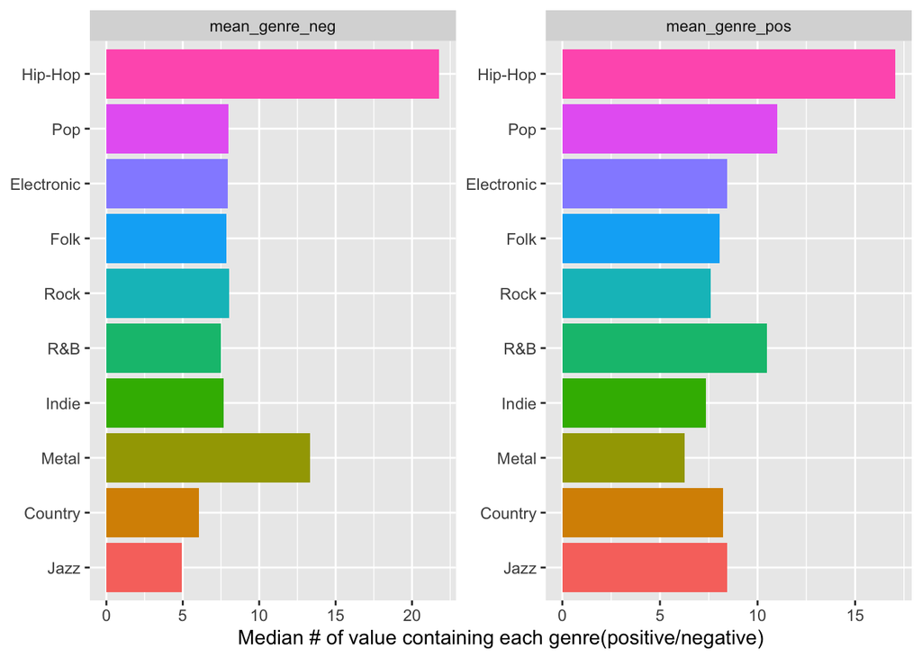

```r
meansentiment_genre %>%
  pivot_longer(cols=c(mean_genre_pos,mean_genre_neg),names_to = "sentiment",values_to = "value")%>%
  group_by(sentiment) %>%
  top_n(10, value) %>%
  arrange(value) %>%
  ungroup() %>%
  mutate(genre = factor(genre, unique(genre))) %>%
  ungroup() %>%
  ggplot(aes(genre, value, fill = sentiment)) +
  geom_col(show.legend = FALSE,aes(fill=genre)) +
  facet_wrap(~ sentiment, scales = "free", ncol = 2) +
  coord_flip() +
  labs(x = NULL,
       y = "Median # of value containing each genre(positive/negative)")
```

Through the comparison of the two sets of histograms, we have an initial understanding of the emotional style of each genre:

1. the positive emotional strength of pop music, country music, R & B and jazz is obviously greater than the negative emotional strength, so the style of these three songs should be positive.
2. The negative emotional strength of metal is more significant than the positive emotional strength, so the style of metal music should be negative.
3. we found that hip-hop is a music genre with a lot of emotions, and emotional words are common in lyrics. This is also consistent with our intuitive impression. Compared with folk songs, jazz music and other more narrative songs, hip hop music mainly expresses people’s attitude.

As a master student in statistics , we try to perform statistical analysis and do correlation test

```r
genre_word_df=tidy(corpus1) %>%
  select(id,text)%>%
  left_join(dt_lyrics,by="id")%>%
  select(id,genre,text)%>%
  unnest_tokens(word, text)%>%
  mutate(int=row_number())
test_genre=genre_word_df%>%
  inner_join(get_sentiments("bing"),by = "word")%>%
  filter(!genre=="Not Available")%>%
  filter(!genre=="Other")%>%
  mutate(genre=as.factor(genre))%>%
  mutate(sentiment=as.factor(sentiment))
test_genre
```

```
## # A tibble: 2,212,635 x 5
##    id    genre   word     int sentiment
##    <chr> <fct>   <chr>  <int> <fct>
##  1 1     Hip-Hop fast      52 positive
##  2 1     Hip-Hop loving    71 positive
##  3 1     Hip-Hop cry       89 negative
##  4 1     Hip-Hop wrong    107 negative
##  5 2     Hip-Hop unsure   111 negative
##  6 2     Hip-Hop lead     118 positive
##  7 2     Hip-Hop dies     127 negative
##  8 2     Hip-Hop sad      141 negative
##  9 2     Hip-Hop good     142 positive
## 10 2     Hip-Hop guilty   149 negative
## # … with 2,212,625 more rows
```

```r
mytable1 <- xtabs(~sentiment+genre, data=test_genre)
chisq.test(mytable1)
```

```
##
##  Pearson's Chi-squared test
##
## data:  mytable1
## X-squared = 49891, df = 9, p-value < 2.2e-16
```

```r
mytable1
```

```
##           genre
## sentiment  Country Electronic   Folk Hip-Hop  Indie   Jazz  Metal    Pop
##   negative   45704      22298   4037  194011  10139  20363 150713 149262
##   positive   62051      23790   4143  151901   9674  34836  70807 205975
##           genre
## sentiment     R&B   Rock
##   negative  16253 521838
##   positive  22784 492056
```

At this time, sentiment and genre are both categorical variables. after Pearson’s Chi-squared test,p-value < 2.2e-16. So it passed the correlation test.

Thus the sentiment of the lyrics is related to genre.

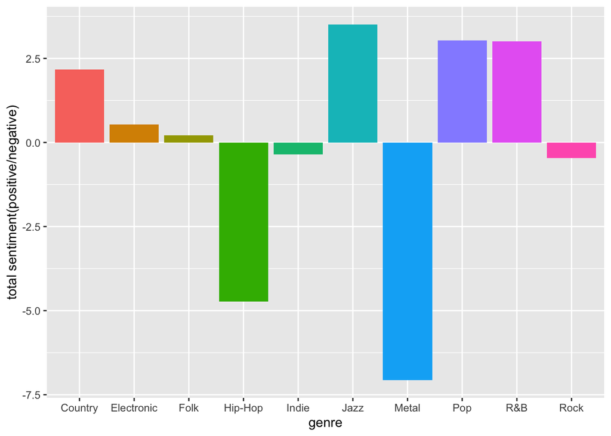

```r
total_sentiment_genre=meansentiment_genre%>%
  mutate(total=mean_genre_pos-mean_genre_neg)%>%
  select(genre,total)

total_sentiment_genre%>%
  ggplot(aes(genre, total, fill = genre)) +
  geom_col(show.legend = FALSE) +
  labs(x = "genre",y="total sentiment(positive/negative)")
```

we counted the emotions of songs in different genres. Observing the emotions that different genres convey to people under common circumstances, it is concluded that country, jazz, pop, and R&B are songs with highly positive sentiments. This is consistent with our preliminary guess earlier. Electronic and folk music are songs with soft positive sentiments, rock and indie are songs with soft negative sentiments, while Hip-hop and metalare songs with strong negative sentiments.

This is basically the same as how we feel when listening to music.When we’re at a party, we often choose Jazz music, which represents carnival. When we are happy, we often choose pop, R&B or country music which conveys joy and relaxed emotions. When we are angry or feel pressure, we often choose hip-hop or metal music which often expresses sadness, anger, or helplessness emotion to resolve emotions.

```r
genre_word_df=tidy(corpus1) %>%
  select(id,text)%>%
  left_join(dt_lyrics,by="id")%>%
  select(id,genre,text)%>%
  unnest_tokens(word, text)%>%
  mutate(int=row_number())
```

We also found that this was an overall effect. Take country music as an example. At the same time, there are 62051 positive words and 45704 negative words appear in all country songs in total.

###3. sentimental changes in a whole song among different genres.

With this in mind, and continuing to dig deeper into the sentiment of text, what we do next is: Analyze how sentiment showed by lyrics changes throughout the song by different genre(the time when their positive words and negative words appear),and draw a curve flow chart. We know that even if a few words are positive words, there are profound differences between them. In order to better reflect the level of emotion, we use the afinn dictionary for word and emotion correspondence at this time.

```r
afinn_pos<-get_sentiments("afinn") %>%
  filter(value>0)
afinn_neg<-get_sentiments("afinn") %>%
  filter(value<0)

count_pos_genre<-genre_word_df%>%
  inner_join(afinn_pos,by = "word")
count_neg_genre<-genre_word_df%>%
  inner_join(afinn_neg,by = "word")

sort_genre=bind_rows(count_neg_genre,count_pos_genre)%>%
  group_by(genre)%>%
  mutate(number=as.integer(int))%>%
  ungroup()%>%
  select(-int)%>%
  mutate(id=as.integer(id))%>%
  arrange(id)
sum_word=word_df%>%
  mutate(id=as.integer(id))%>%
  count(id) %>%
  mutate(csum = cumsum(n)) %>%
  mutate(csum = c(0,csum[1:(length(csum)-1)]))
rate_genre=sort_genre%>%
  left_join(sum_word,by="id")%>%
  mutate(rate=(number-csum)/n)%>%
  select(genre,value,rate)
rate_genre
```

```
## # A tibble: 2,457,313 x 3
##    genre   value   rate
##    <chr>   <dbl>  <dbl>
##  1 Hip-Hop    -1 0.0187
##  2 Hip-Hop    -1 0.832
##  3 Hip-Hop    -1 0.935
##  4 Hip-Hop    -2 1
##  5 Hip-Hop     1 0.346
##  6 Hip-Hop     2 0.514
##  7 Hip-Hop     2 0.664
##  8 Hip-Hop    -1 0.0133
##  9 Hip-Hop    -2 0.113
## 10 Hip-Hop    -3 0.140
## # … with 2,457,303 more rows
```

```r
sequence_genre=rate_genre%>%
  mutate(number=row_number())%>%
  mutate(number=ifelse(rate<0.2,1,number))%>%
  mutate(number=ifelse(rate>=0.2&rate<0.4,2,number))%>%
  mutate(number=ifelse(rate>=0.4&rate<0.6,3,number))%>%
  mutate(number=ifelse(rate>=0.6&rate<0.8,4,number))%>%
   mutate(number=ifelse(rate>=0.8&rate<=1,5,number))
sequence_genre_group=sequence_genre%>%
  select(-rate)%>%
  group_by(genre,number)%>%
  summarise(mean= mean(value))%>%
  filter(!genre=="Not Available")%>%
  filter(!genre=="Other")
sequence_genre_group
```

```
## # A tibble: 50 x 3
## # Groups:   genre [10]
##    genre      number  mean
##    <chr>       <dbl> <dbl>
##  1 Country         1 0.418
##  2 Country         2 0.496
##  3 Country         3 0.489
##  4 Country         4 0.512
##  5 Country         5 0.609
##  6 Electronic      1 0.196
##  7 Electronic      2 0.243
##  8 Electronic      3 0.217
##  9 Electronic      4 0.309
## 10 Electronic      5 0.316
## # … with 40 more rows
```

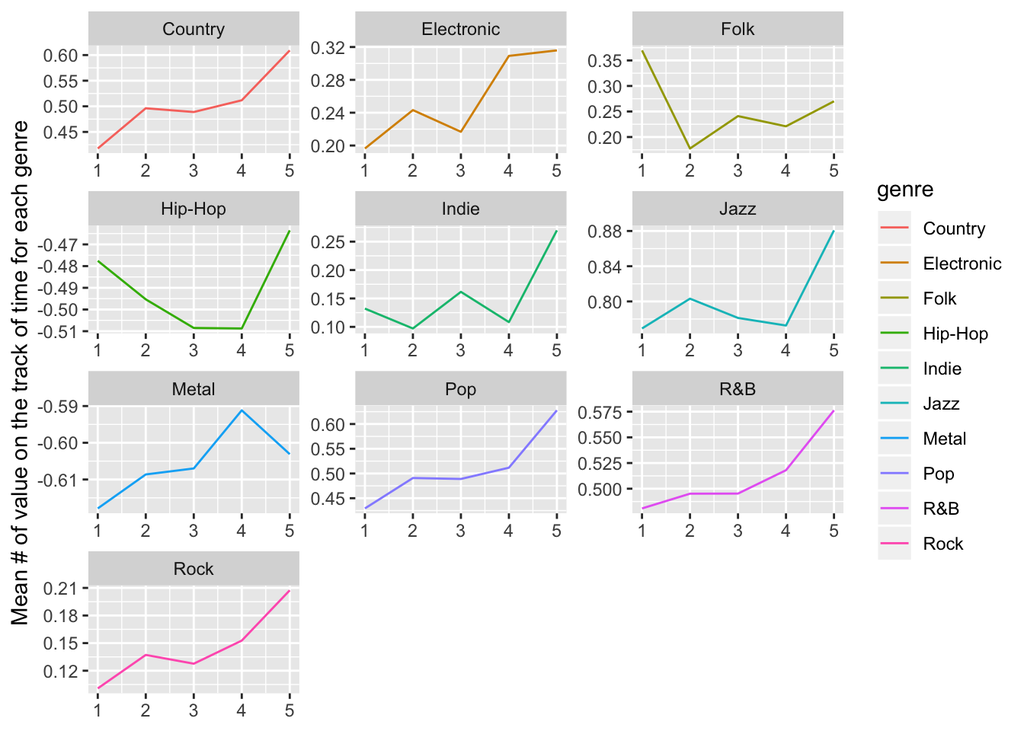

```r
sequence_genre_group%>%
  ggplot(aes(number,mean)) +
  geom_line(aes(color=genre)) +
  facet_wrap(~genre, scales = "free", ncol = 3) +
  labs(x = NULL,
       y = "Mean # of value on the track of time for each genre ")
```

###4. Contribution Analysis by affin

At this time, we use the afinn dictionary to analyze the contribution of positive affective words and negative affective words in the database.

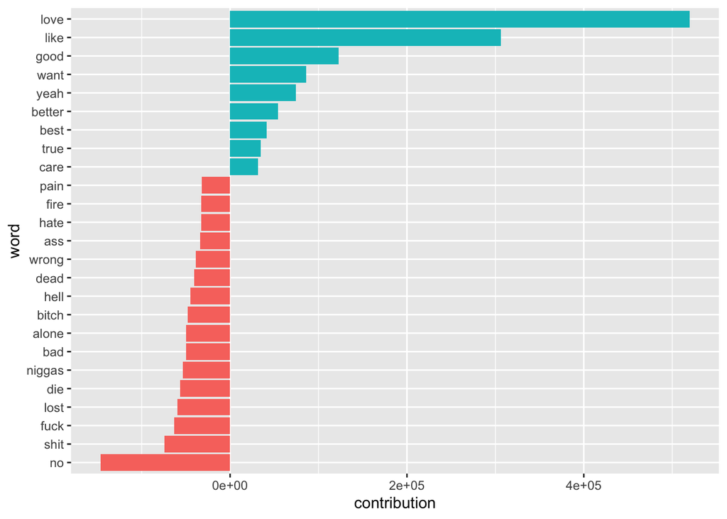

```r
contributions <- word_df%>%
  inner_join(get_sentiments("afinn"), by = "word") %>%
  group_by(word)%>%
  summarize(occurences = n(),
            contribution = sum(value))

contributions %>%
  top_n(25, abs(contribution)) %>%
  mutate(word = reorder(word, contribution)) %>%
  ggplot(aes(word, contribution, fill = contribution > 0)) +
  geom_col(show.legend = FALSE) +
  coord_flip()
```

we can find the words with the greatest contributions to positive/negative sentiment values in the lyrics dataset.These words look generally reasonable as indicators of each genre/ages/song’s sentiment.

first, we can calculate each word’s contribution to each genre’s sentiment score, and visualize the strongest contributors from a selection of the groups.

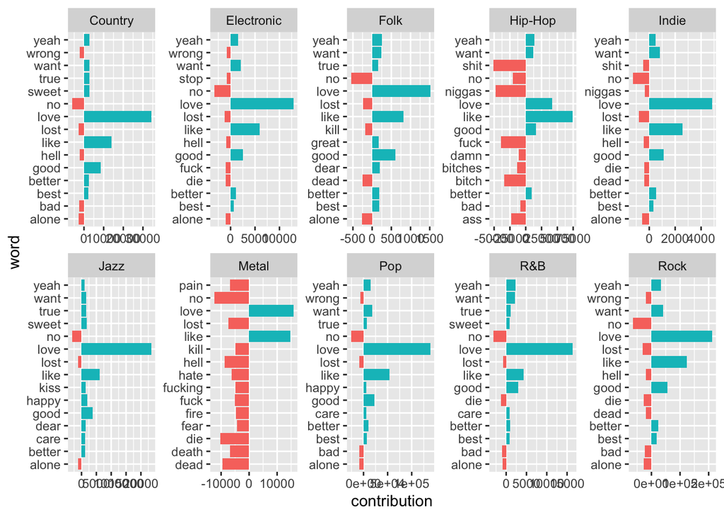

```r
contributions_genre=genre_word_df%>%
  inner_join(get_sentiments("afinn"), by = "word") %>%
  group_by(genre,word)%>%
  summarize(occurences = n(),
            contribution = sum(value))%>%
  filter(!genre=="Not Available")%>%
  filter(!genre=="Other")

contributions_genre %>%
  top_n(15, abs(contribution)) %>%
  mutate(word = reorder(word, contribution)) %>%
  ggplot(aes(word, contribution, fill = contribution > 0)) +
  geom_col(show.legend = FALSE) +
  facet_wrap(~genre, scales = "free", ncol = 5) +
  coord_flip()
```

To be specific:

1. Country music and folk songs, as well as R & B music are similar in terms of words, that is to say, the words are relatively subtle, often using such as yeah, sweet, better, want to express joy, while using alone, no, kill, lost to express sadness.
2. Jazz and pop music are more direct. For example, they express joy in direct words such as happy.
3. Rock music and electronic music are similar, and their word maps as above are very similar.
4. Hip hop music and indie are very similar in terms of words , because they often use shit, niggas, shit, bitch, expressed dissatisfaction with rude words.
5. Metal as the main expression of negative emotion music, sadness or dissatisfaction with many words, such as pain, hate, fuck, death, fear and so on. In addition, the lyrics often contain fire, giving a very strong psychological impact.
6. Generally speaking, lyrics are often used in love, like to express positive emotions, and no to directly express negative emotions.

Therefore, as we can image, the music genres are connected to sentiments in lyrics.

###5.The position of words with larger sentimental contributions

Based on this, we naturally asked a question: since the sentiment of the lyrics is related to words, is it that most frequently used positive-words like “love”,“like”,“want”,“good”,“happy” appear more at the end, and most commonly used negative-words like “wrong”,“no”,“alone”,“bad”,“lost”, in What more appears at the beginning or middle? So, I will explore where these words appear in different genres.

```r
s0=sort_genre%>%
  left_join(sum_word,by="id")%>%
  mutate(rate=(number-csum)/n)%>%
  select(word,genre,value,rate)%>%
  filter(word==c("love","like","want","good","happy","wrong","no","alone","bad","lost"))%>%
  mutate(number=row_number())%>%
  mutate(number=ifelse(rate<0.2,1,number))%>%
  mutate(number=ifelse(rate>=0.2&rate<0.4,2,number))%>%
  mutate(number=ifelse(rate>=0.4&rate<0.6,3,number))%>%
  mutate(number=ifelse(rate>=0.6&rate<0.8,4,number))%>%
   mutate(number=ifelse(rate>=0.8&rate<=1,5,number))%>%
  mutate(senti=ifelse(value>0,"positive","negative"))%>%
  filter(!genre=="NA")%>%
  filter(!genre=="Not Available")%>%
  filter(!genre=="Other")%>%
  select(-value,-rate)%>%
  group_by(genre,word,number,senti)%>%
  count()%>%
  ungroup()%>%
  group_by(genre,word)
s0
```

```
## # A tibble: 494 x 5
## # Groups:   genre, word [100]
##    genre   word  number senti        n
##    <chr>   <chr>  <dbl> <chr>    <int>
##  1 Country alone      1 negative    29
##  2 Country alone      2 negative    24
##  3 Country alone      3 negative    25
##  4 Country alone      4 negative    31
##  5 Country alone      5 negative    29
##  6 Country bad        1 negative    17
##  7 Country bad        2 negative    13
##  8 Country bad        3 negative    14
##  9 Country bad        4 negative    13
## 10 Country bad        5 negative    17
## # … with 484 more rows
```

```r
s1=s0%>%
  group_by(genre,word)%>%
  filter(n==max(n))%>%
  mutate(number=ifelse(n==n,mean(number),number))%>%
  distinct()
s1
```

```
## # A tibble: 100 x 5
## # Groups:   genre, word [100]
##    genre   word  number senti        n
##    <chr>   <chr>  <dbl> <chr>    <int>
##  1 Country alone      4 negative    31
##  2 Country bad        3 negative    17
##  3 Country good       5 positive    63
##  4 Country happy      3 positive    17
##  5 Country like       2 positive   164
##  6 Country lost       4 negative    26
##  7 Country love       5 positive   293
##  8 Country no         4 negative   135
##  9 Country want       4 positive    60
## 10 Country wrong      2 negative    22
## # … with 90 more rows
```

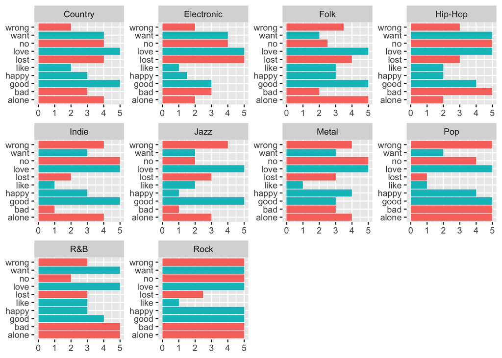

```r
s1%>%
  ggplot(aes(word,number,fill=senti)) +
  geom_col(show.legend = FALSE) +
  facet_wrap(~genre, scales = "free", ncol = 4) +
  labs(x = NULL,
       y = NULL)+
  coord_flip()
```

1. From the figure we can find that in country music, the words love and good are mostly used in the fifth paragraph, and because of their high positive emotional score, the final mood of country music is very high. In general, positive words such as want, happy, etc. often appear in the middle to the final stage. At the same time, the middle part is accompanied by negative words such as no, bad, lost, making the emotions not very positive in this stage.
2. In electronic music, at the beginning, positive words prevailed (the green part is the main part from 0 to 2. Later, negative words were gradually added, which led to emotional depression. In addition, although both love and lost appeared more often in at the end of the song, because in the direction of their emotions, love expresses deeper than lost, thus suppressing negative emotions, so the emotions gradually rise again.
3. The meaning of folk music is not very consistent with the result of our previous song images.Since the first paragraph does not include the vocabulary we have chosen, we suspect that this may be because the way of expressing positive emotions in folk music is more peaceful. For example, it often uses the words “dear” and “miss”, but they are not included in the range we have selected. In addition, it can be clearly felt that after the second paragraph, the mood of folk music fluctuates in a gentle trend within a low positive emotion.
4. Hip-hop, indie and jazz music are kind of similar. Both positive words and negative words coexist at the beginning. Later, words gradually decrease. After the fourth part, very strong positive words such as love are added, thus making emotions rise.
5. The charts of Pop and R & B are also very similar, which is consistent with the result of our previous song images.And the overall positive emotions are gradually rising.
6. Rock music is a bit weird. We found that the common emotional words like wrong, want, no, love, happy, good, bad, and alone appear almost at the very end. This is also logical. Generally speaking, the emotion of rock music is from light to strong, and the emotion is released as the song continues.

###6.sentimental changes in different ages

First we examine the correlation between emotion and age

```r
genre_n_selected = genre_n%>%
  filter(!genre=="Not Available"&!genre=="Other")

dt_lyrics_ages<-dt_lyrics%>%
  filter(year>=1970)%>%
  mutate(ages=row_number())%>%
  mutate(ages=ifelse(year<1980,"1970s",ages))%>%
  mutate(ages=ifelse(year>=1980,"1980s",ages))%>%
  mutate(ages=ifelse(year>=1990,"1990s",ages))%>%
  mutate(ages=ifelse(year>=2000,"2000s",ages))%>%
  mutate(ages=ifelse(year>=2010,"2010s",ages))
dt_lyrics_ages
```

```
## # A tibble: 125,701 x 8
##    song     year artist genre  lyrics        id    stemmedwords       ages
##    <chr>   <dbl> <chr>  <chr>  <chr>         <chr> <chr>              <chr>
##  1 when-y…  2009 a      Hip-H… "I stopped b… 1     stop house call h… 2000s
##  2 carele…  2009 a      Hip-H… "I feel so u… 2     unsure hand lead … 2000s
##  3 2-59     2007 a      Hip-H… "Mark:] Sund… 3     mark sunday footb… 2000s
##  4 power-…  2007 a      Hip-H… "[Chris:] Fa… 4     chris fallin fant… 2000s
##  5 you-re…  2007 a      Hip-H… "something i… 5     touch hold hand h… 2000s
##  6 nothing  2007 a      Hip-H… "Nothing\nAn… 6     nothings youre yo… 2000s
##  7 bad-bi…  2013 a      Hip-H… "(Hahahaha)\… 7     hahahaha ghetto s… 2010s
##  8 strang…  2013 a      Hip-H… "If it's one… 8     ive learn ive wri… 2010s
##  9 better…  2005 a      Hip-H… "Run around,… 9     run whats frequen… 2000s
## 10 die-to…  2005 a      Hip-H… "Lose yourse… 10    lose save night t… 2000s
## # … with 125,691 more rows
```

```r
corpus_ages<- VCorpus(VectorSource(dt_lyrics_ages$lyrics))
#create a tidy data structure
word_text_ages<- tidy(corpus_ages) %>%
  select(id,text)
#break the text into individual tokens
ages_genre_word_df=word_text_ages%>%
  left_join(dt_lyrics_ages,by="id")%>%
  select(genre,text,ages)%>%
  filter(!genre=="Not Available"&!genre=="Other")%>%
  unnest_tokens(word, text)
ages_genre_word_df
```

```
## # A tibble: 28,237,682 x 3
##    genre   ages  word
##    <chr>   <chr> <chr>
##  1 Hip-Hop 2000s i
##  2 Hip-Hop 2000s stopped
##  3 Hip-Hop 2000s by
##  4 Hip-Hop 2000s the
##  5 Hip-Hop 2000s house
##  6 Hip-Hop 2000s we
##  7 Hip-Hop 2000s called
##  8 Hip-Hop 2000s our
##  9 Hip-Hop 2000s home
## 10 Hip-Hop 2000s it
## # … with 28,237,672 more rows
```

```r
test_genre=ages_genre_word_df%>%
  inner_join(get_sentiments("bing"),by = "word")%>%
  filter(!genre=="Not Available")%>%
  filter(!genre=="Other")%>%
  mutate(ages=as.factor(ages))%>%
  mutate(sentiment=as.factor(sentiment))
test_genre
```

```
## # A tibble: 2,212,515 x 4
##    genre   ages  word   sentiment
##    <chr>   <fct> <chr>  <fct>
##  1 Hip-Hop 2000s fast   positive
##  2 Hip-Hop 2000s loving positive
##  3 Hip-Hop 2000s cry    negative
##  4 Hip-Hop 2000s wrong  negative
##  5 Hip-Hop 2000s unsure negative
##  6 Hip-Hop 2000s lead   positive
##  7 Hip-Hop 2000s dies   negative
##  8 Hip-Hop 2000s sad    negative
##  9 Hip-Hop 2000s good   positive
## 10 Hip-Hop 2000s guilty negative
## # … with 2,212,505 more rows
```

```r
mytable2 <- xtabs(~sentiment+ages, data=test_genre)
chisq.test(mytable2)
```

```
##
##  Pearson's Chi-squared test
##
## data:  mytable2
## X-squared = 1487.9, df = 4, p-value < 2.2e-16
```

```r
mytable2
```

```
##           ages
## sentiment   1970s  1980s  1990s  2000s  2010s
##   negative   7664   9913  33980 835015 248030
##   positive  10266   9777  37437 772985 247448
```

At this time, sentiment and ages are both categorical variables. after Pearson’s Chi-squared test,p-value < 2.2e-16, passed statistical correlation testThus the sentiment of the lyrics is related to ages.

###(1).among different genre

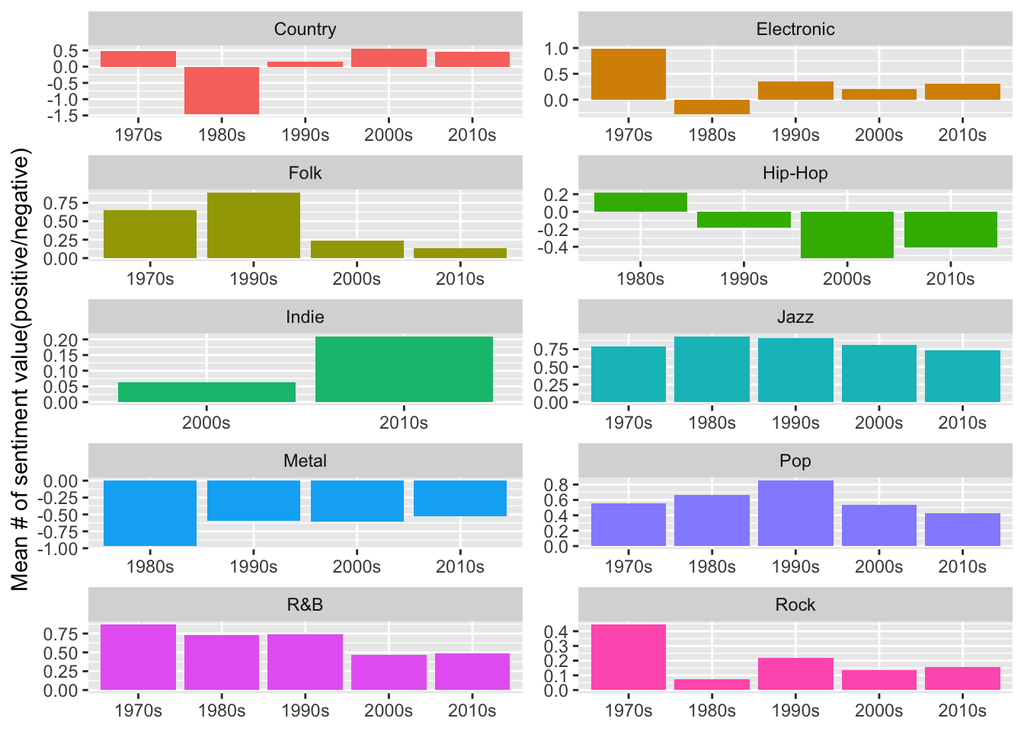

```r
count_pos_ages_genre<-ages_genre_word_df%>%
  inner_join(afinn_pos,by = "word")
count_neg_ages_genre<-ages_genre_word_df%>%
  inner_join(afinn_neg,by = "word")
sort_ages_genre=bind_rows(count_neg_ages_genre,count_pos_ages_genre)%>%
  group_by(genre,ages)%>%
  summarise(sum=sum(value),
            mean=mean(value))%>%
  filter(!genre=="NA")%>%
  ungroup()

sort_ages_genre%>%
  ggplot(aes(ages,mean,fill=genre)) +
  geom_col(show.legend = FALSE) +
  facet_wrap(~genre, scales = "free", ncol = 2) +
  labs(x = NULL,
       y = "Mean # of sentiment value(positive/negative)")
```

We visualized the emotional changes of different genres over time. From this we find that the emotions expressed by the same genre are also changing with the development of the times and social changes.

To be specific:

1. The music of the three genres of country, electronic, and rock experienced a great emotional decline in the 1980s (even from positive emotions to negative emotions). We suspect that the 1980s may be under the influence of a certain genre The remaining genres were reformed. But in the following 90’s, emotions gradually rose(in positive direction). We speculate that this change may be due to the prevalence and decline of style over time. country，
2. The sentimental changes in jazz and pop music have always been relatively stable, and both have remained at a high level of positive emotions.
3. Indie music has not appeared before, so we think that this genre of music genre may not appear until 2000. And its mood is gradually high-profile.
4. The mood of folk music basically reached its climax in the 1990s, but then gradually fell back and became more moderate.

Next, we can also divide the total emotion (no genre division) according to different ages, so as to observe the influence of the era on the emotion of the lyrics.

###(2). no genre division

```r
ages_word_df=word_text_ages%>%
  left_join(dt_lyrics_ages,by="id")%>%
  select(text,ages)%>%
  unnest_tokens(word, text)

count_pos_ages<-ages_word_df%>%
  inner_join(afinn_pos,by = "word")
count_neg_ages<-ages_word_df%>%
  inner_join(afinn_neg,by = "word")

sort_ages=bind_rows(count_neg_ages,count_pos_ages)%>%
  group_by(ages)%>%
  summarise(sum=sum(value),
            mean=mean(value))%>%
  filter(!ages=="NA")%>%
  ungroup()
sort_ages
```

```
## # A tibble: 5 x 3
##   ages     sum   mean
##   <chr>  <dbl>  <dbl>
## 1 1970s  11321 0.525
## 2 1980s   4120 0.191
## 3 1990s  21548 0.269
## 4 2000s 126029 0.0711
## 5 2010s  64441 0.115
```

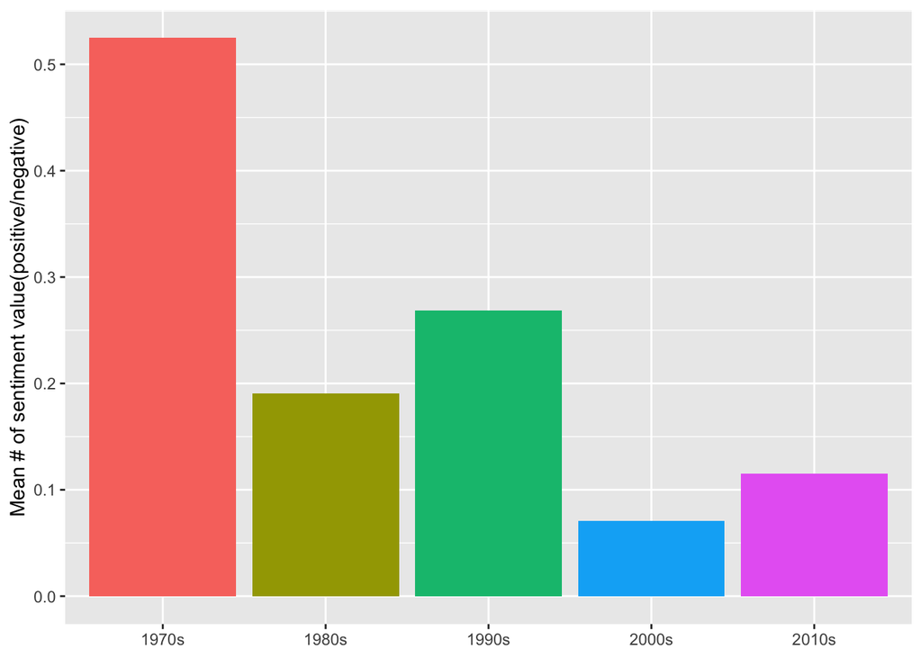

```r
sort_ages%>%
  ggplot(aes(ages,mean,fill=ages)) +
  geom_col(show.legend = FALSE)+
  labs(x = NULL,
       y = "Mean # of sentiment value(positive/negative)")
```

For music of different ages, sentiments are also different.

With the passage of time, the overall positive emotions of the song gradually weaken, but at the same time, there will be small fluctuations with what happens around the world. Such as the economic depression of the country and so on, will affect the composition of songs.

But in general, living a peaceful life and better and better economic development, people will focus more on their negative emotions, and also people’s appreciation of music and their tolerance will increase. Songs that express negative emotions are accepted by people. At the same time, with the rapid development of the times, people’s life pressures increase, more negative songs are needed to release anger or sadness, and people have more courage to express their singing.